# CSIRO WORKFORCE

Using SAP data to analyse the CSIRO Workforce

Elise Behn

People Insights

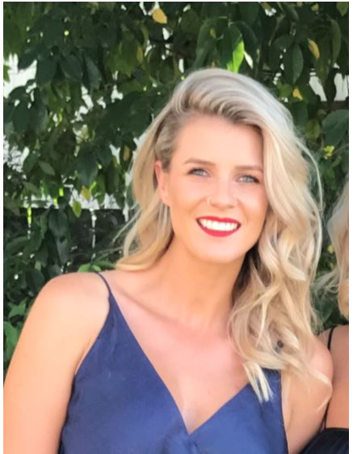

# Introduction

My name is Elise Behn and I have been working with data for the past 6 years of my career, up until this point I have been mostly focused on analysing, storing and manipulating the data through available systems such as Excel. I decided to enrol in Data School for the chance to build my skills around data collection, visualisation, analysis and more importantly learn about the programming languages used to perform these tasks behind the scenes. Our team hope to be using more advanced technologies for our reporting in the near future and I believe having these types of skills will truly benefit my understanding of newer systems on the market. Before stating the Focus program i had no experience in R nor any other computer programming language. My days were spent generating reports from SAP and manipulating them in Excel. Since Focus i have already transformed the way i work from data management to simplifying repetitive processes.

# My Project

My project is looking at transforming how our team use our data. We are in the midst of recreating the CSIRO HR Dashboards so i have used this opportunity to start working with wrangling the multiple reports that are used to form the dashboard. for the purposes of this project i have thrown in some graphs to represent the type of data i am using but used the time to really clean up the reports to make them useable.

[figure not shown]

[figure not shown]

Figure 2: CSIRO WORKFORCE

[figure not shown]

# My Digital Toolbox

Tidyverse, ggplot, ggannimate

# My time went …

My time in R has been spent playing with my source data and trying to work out how to make some interesting graphs in R from it. Surprisingly it wasn’t as easy as it would be in excel to put together a couple graphs so show my data beacause it always seemed to be in the wrong format requiring further manipulation.

# Next steps

# My Data School Experience

i truley enjoyed my Data School experience, within the first few weeks i was already putting my new skills into action in my job and every week since then i have been building onto those skills figuring out better ways our team can improve/ simplfy and automate our processes.